# Shaikh_ALY6000Project2

# Task 6

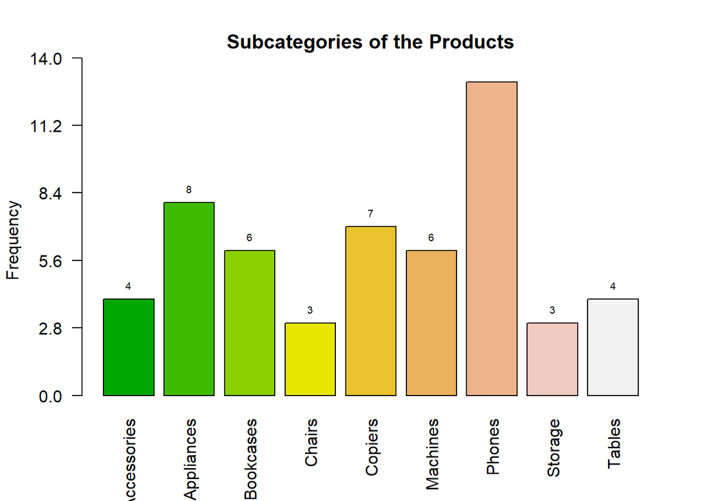

```r
t5_table = table(t4Africa$Product_SubCategory)
t5_bar = barplot(t5_table,
     main = "Subcategories of the Products",
     ylab = "Frequency",
     xlab = "",
     col = terrain.colors(9),
     las = 2,
     yaxp = c(0,14,5),2)
text(y=table(t4Africa$Product_SubCategory),
     t5_bar,
     table(t4Africa$Product_SubCategory),
     cex = 0.6,
     pos = 3)
```

**Observations**: We have successfully updated the table with labels and made it better looking by adding some colors in it.

# Task 7

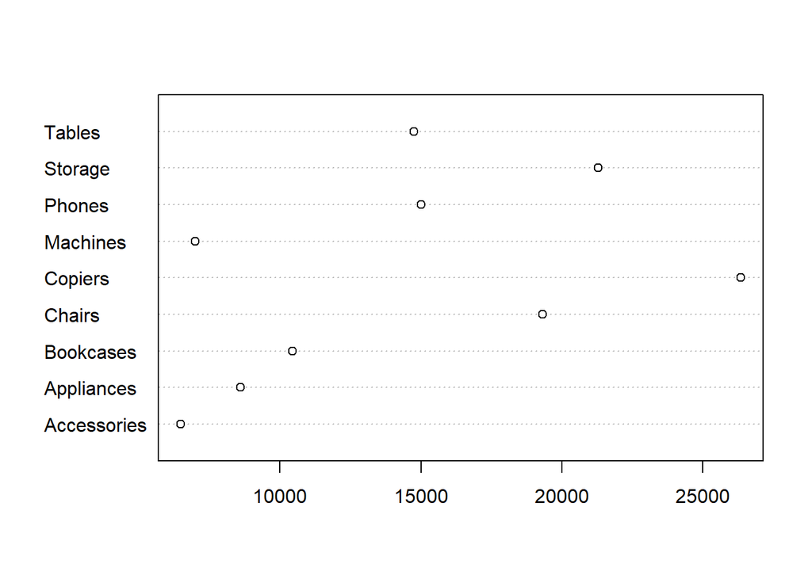

```r
mean_sales = tapply(t4Africa$Sales, t4Africa$Product_SubCategory, mean)
dotchart(mean_sales)
```

**Observations**: Successfully created the the required dot plot for this task for the Africa table.

# Task 8

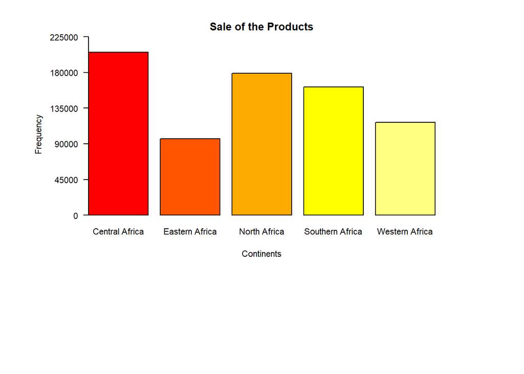

```r
Sales_Africa = tapply(t4Africa$Sales, t4Africa$Region, sum)
par(mai = c(2.1,1,0.7,1),
    cex = 0.7)
barplot(Sales_Africa,
     main = "Sale of the Products",
     ylab = "Frequency",
     xlab = "Continents",
     col = heat.colors(5),
     yaxp = c(0,225000,5),
     las = 1,
     pos = 0.2,
     )
```

**Observations**: Used the tapply() and sum function to get the total sales per region in the African Market where we get the data of Central Africa getting the highest number of sales when compared to other parts of the continent.

# Task 9

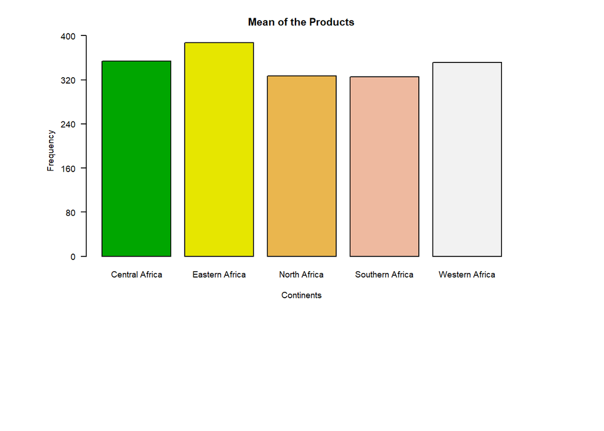

```r
Means_Africa = tapply(t4Africa$ShippingCost, t4Africa$Region,  mean)
par(mai = c(2,1,0.5,1),
    cex = 0.6)
barplot(Means_Africa,
     main = "Mean of the Products",
     ylab = "Frequency",
     xlab = "Continents",
     col = terrain.colors(5),
     las = 1,
     yaxp = c(0,400,5),2)
```

**Observations**: Successfully got the mean shipping costs per region in the african market where we get the data that eastern africa has the most frequency of mean shipping costs when compared to the rest of the continent.

# Task 10

**Data Type designations in R**  
:  
*Numeric:*The most widely used and familiar data type in R is the Numeric Data type. These hold all the values that either are numbers or use the decimel system when using R which needs to be used and executed for certain function.  
*Factor:*The factor is used when there is need for character or text variables when using R. Factor variables, are employed when there are a restricted amount of distinct character strings.  
*Double:*R turns a number into a “double” value or a decimal type with at least two decimal places when it saves it in a variable.([2] geeksforgeeks.com, 2023)  
*Integer:*This data type deals with only numbers whereas Numeric data types deals with numbers as well as a decimel, this tends to only deals with values that don’t hold decimal values. ([1] statsandr.com, 2023)

# Task 11

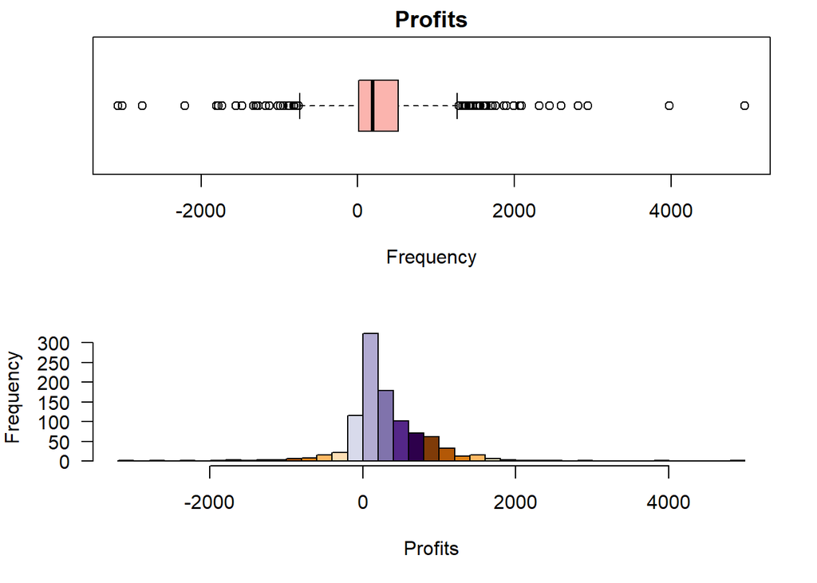

```r
par(mfcol=c(2,1),
   mai = c(2, 1, 2, 0.4),
   mar = c (5,4,1.6,2))

# Box-Plot
boxplot(M2Data$Profits,
        main = "Profits",
        xlab = "Frequency",
     col = brewer.pal(3, "Pastel1"),
     horizontal = T
     )

# Histogram
hist(M2Data$Profits,
     breaks = 50,
     xlab = "Profits",
     col = brewer.pal(10, "PuOr"),
     las = 1,
     yaxp = c(0,300,5),2,
     main = "" )
```

**Observations**: Successfully written the code provided by the Professor where we can observe that the graphs are missing some of the labels and can be made better by using some of the colors present in the Rbrewer libraries.

# Task 12

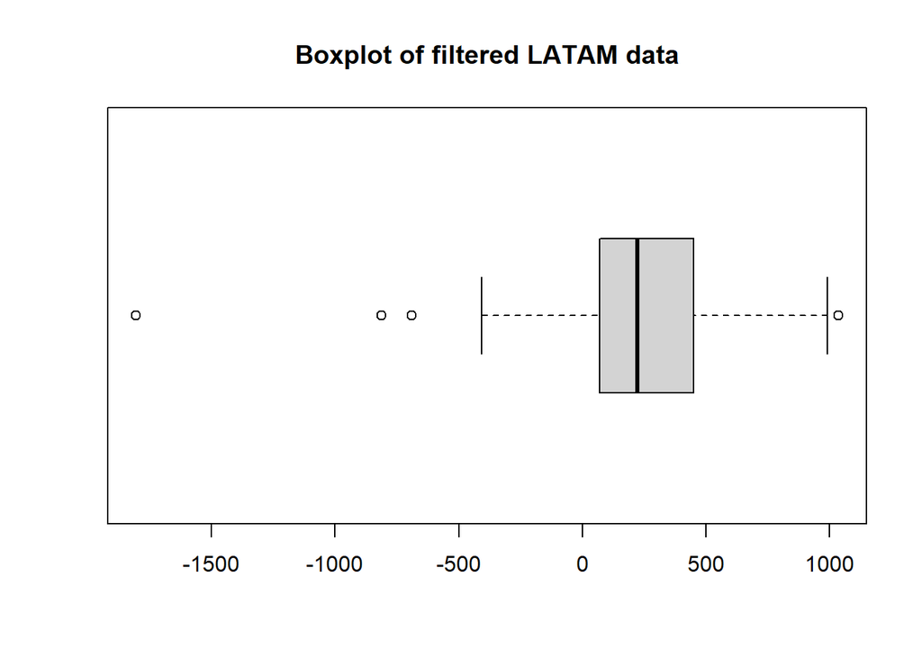

```r
LATAM_Profits = dplyr::filter(M2Data, Market=="LATAM")
t13LATAM = filter(LATAM_Profits)
boxplot(t13LATAM$Profits,
        main = "Boxplot of filtered LATAM data",
        horizontal = T)
```

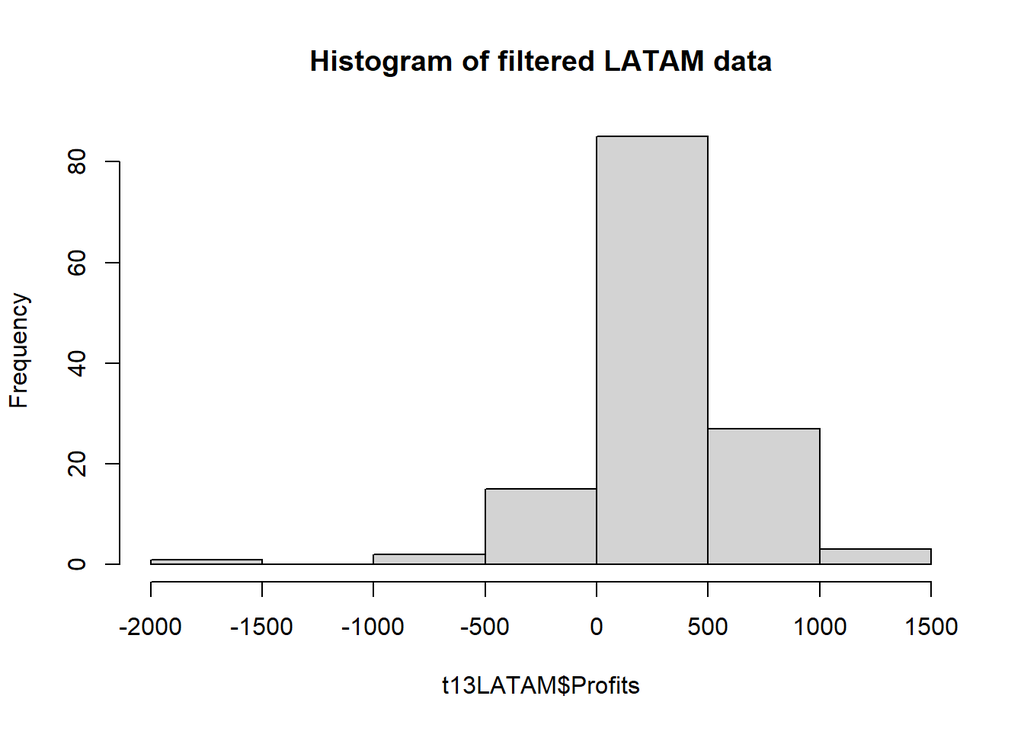

```r
hist(t13LATAM$Profits,
     main = "Histogram of filtered LATAM data",
     )
```

**Observations**: Filtered the data for Latin America successfully and stored in a new variable or subset “t13LATAM” for using it in further tasks.

# Task 13

```r
salestot_Latam = tapply(t13LATAM$Sales, t13LATAM$Region, sum)
knitr::kable(salestot_Latam)
```

|  | x |
| --- | --- |
| Caribbean | 196775.2 |
| Central America | 924226.2 |
| South America | 457623.3 |

**Observations**: Using the table generated bvefore we have successfully made the table for Latin America total sales values.

# Task 14

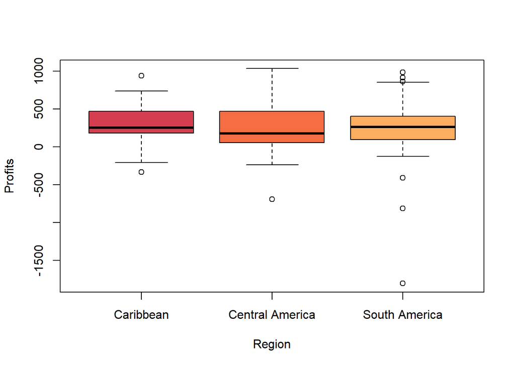

```r
boxplot(Profits ~ Region, data=t13LATAM,
        col = brewer.pal(9, "Spectral"))
```

**Observations**: Successfully presented the boxplots from the filtered subset that shoes the profits in the form of boxplots and also giving it colors to make it more readable or understandable.

# Task 15

```r
t15 = M2Data$Product_SubCategory%>%
  table() %>%
  as.data.frame()%>%
  rename (Frequency = Freq)%>%
  mutate (Cumulative_fre = cumsum (Frequency),
          Probabilty = Frequency/nrow(M2Data),
          Cumulative_prob = cumsum (Probabilty))

knitr::kable(t15,
             digits = 2,
             caption = "Product Categories",
             format = "html",
             table.attr = "style='width:40%;'",
             align = 'c') %>%
 kable_classic(bootstrap_options = "striped",
              full_width = TRUE,
              position = "center",
              font_size = 12)
```

Product Categories

| . | Frequency | Cumulative_fre | Probabilty | Cumulative_prob |
| --- | --- | --- | --- | --- |
| Accessories | 38 | 38 | 0.04 | 0.04 |
| Appliances | 125 | 163 | 0.12 | 0.16 |
| Art | 18 | 181 | 0.02 | 0.18 |
| Binders | 38 | 219 | 0.04 | 0.22 |
| Bookcases | 130 | 349 | 0.13 | 0.35 |
| Chairs | 95 | 444 | 0.10 | 0.44 |
| Copiers | 126 | 570 | 0.13 | 0.57 |
| Envelopes | 2 | 572 | 0.00 | 0.57 |
| Fasteners | 6 | 578 | 0.01 | 0.58 |
| Furnishings | 14 | 592 | 0.01 | 0.59 |
| Labels | 6 | 598 | 0.01 | 0.60 |
| Machines | 52 | 650 | 0.05 | 0.65 |
| Paper | 32 | 682 | 0.03 | 0.68 |
| Phones | 179 | 861 | 0.18 | 0.86 |
| Storage | 45 | 906 | 0.04 | 0.91 |
| Supplies | 7 | 913 | 0.01 | 0.91 |
| Tables | 87 | 1000 | 0.09 | 1.00 |

**Observations**: We have created the tables with proper formatting and values.

# Task 16

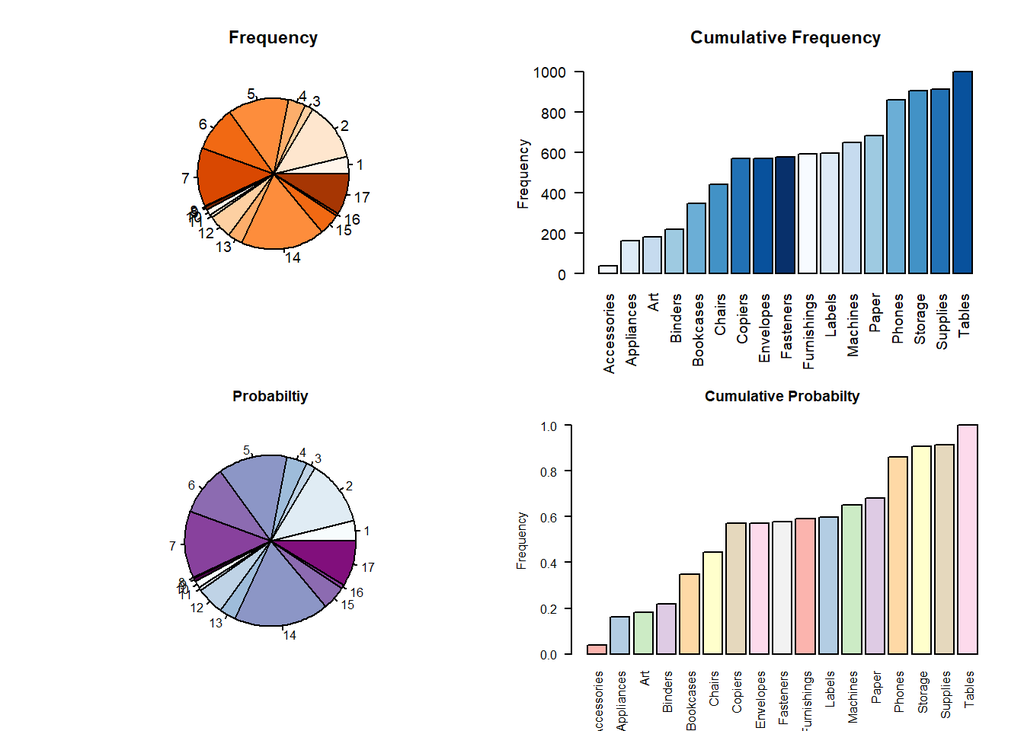

```r
par (mfrow =c(2,2))
t15 = M2Data$Product_SubCategory%>%
  table() %>%
  as.data.frame()%>%
  rename (Frequency = Freq)%>%
  mutate (Cumulative_fre = cumsum (Frequency),
          Probability = Frequency/nrow(M2Data),
          Cumulative_prob = cumsum (Probability))

par(cex = 0.6)
pie(t15$Frequency,
    main = "Frequency",
     col = brewer.pal(9, "Oranges")
     ,)

barplot(t15$Cumulative_fre ~ t15$.,
     main = "Cumulative Frequency",
     ylab = "Frequency",
     xlab = "",
     col = brewer.pal(9, "Blues"),
     las = 2)

par(cex = 0.5)
pie(t15$Probability,
    main = "Probabiltiy",
     col = brewer.pal(9, "BuPu")
     ,)

barplot(t15$Cumulative_prob ~ t15$.,
     main = "Cumulative Probabilty",
     ylab = "Frequency",
     xlab = "",
     col = brewer.pal(9, "Pastel1"),
     las = 2)
```

**Observations**: We created all the required pie charts and Histograms and arranged them using the par(mfrow) function in a layout that makes it better and easier to read.

# Task 17

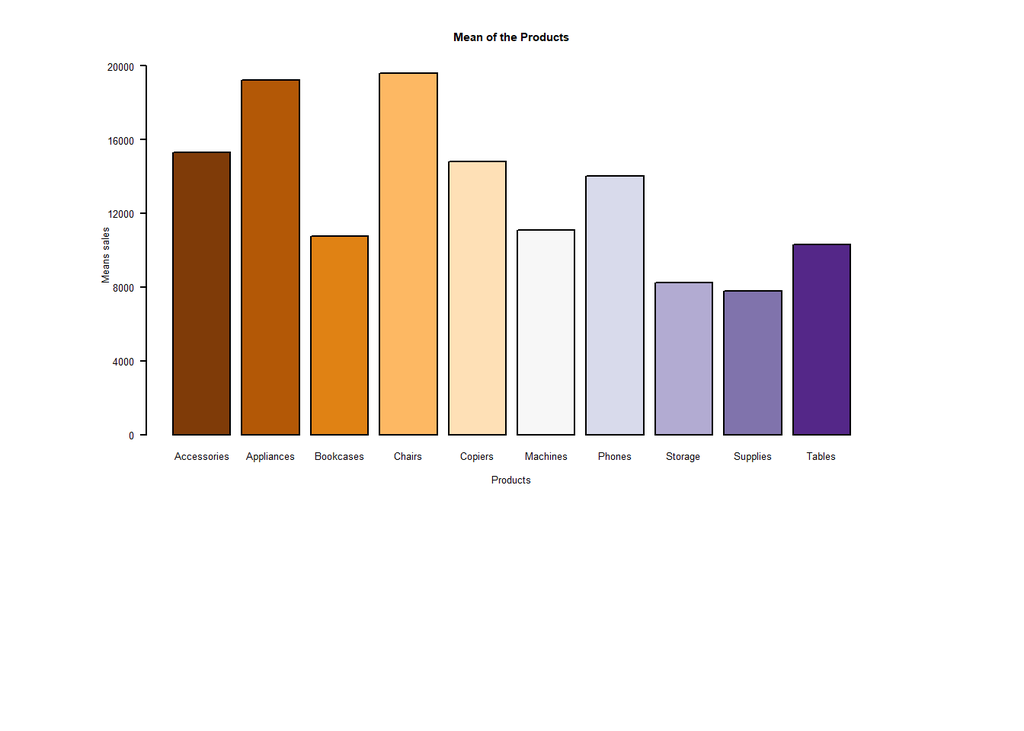

```r
Europe_tot = dplyr::filter(M2Data, Market=="Europe")
mean_sales_eur = tapply(Europe_tot$Sales, Europe_tot$Product_SubCategory, mean)
par(mai = c(2,1,0.5,1),
    cex = 0.4)
barplot(mean_sales_eur,
     main = "Mean of the Products",
     ylab = "Means sales",
     xlab = "Products",
     col = brewer.pal(11, "PuOr"),
     las = 1,
     yaxp = c(0,20000,5),2)
```

**Observations**: We have filtered the data using the M2Data base for Europe and found out the mean of the Sales where we can observe that the most frequency among all the different types is chairs and the least is Supplies.

**Conclusions:**  
I really learnt alot and honestly appreciate these types of assignments where we gain hands on experiences on how to get familiar with R and all the basics of it. Also the range of difficulty was very much interesting where it was easy enough to do with a little research but also tough enough to keep in interesting all the while. Also I would like to add the implementation of html made it ever so interesting and gaining that much more confidence in using the language R henceforth.

**Bibliography:**  
[1] Data types in R (no date) Stats and R. Available at: https://statsandr.com/blog/data-types-in-r/ (Accessed: January 27, 2023).  
[2] R - data types (2022) GeeksforGeeks. GeeksforGeeks. Available at: https://www.geeksforgeeks.org/r-data-types/ (Accessed: January 27, 2023).  
[3] Hillier, W. et al. (2022) Descriptive vs inferential statistics explained, CareerFoundry. Available at: https://careerfoundry.com/en/blog/data-analytics/inferential-vs-descriptive-statistics/#in-summary-whats-the-difference-between-inferential-and-descriptive-statistics (Accessed: January 27, 2023).  
[4] 2011-2023, (c) C.skillsyouneed.com (no date) Presenting data, SkillsYouNeed. Available at: https://www.skillsyouneed.com/present/presenting-data.html (Accessed: January 27, 2023).  
[5] Team, D.F. (2021) Uncover the R applications - why top companies are using R programming, DataFlair. Available at: https://data-flair.training/blogs/r-applications/ (Accessed: January 27, 2023).

Appendix:

- This file also contains an R Markdown file with it. The name of the file is Project2_Shaikh.